# Myungje_Kim_Final_Project

Author

Myungje Kim

# 1. Setup

### Load packages

```r
library(tidyverse)
library(ggplot2)
library(dplyr)
library(pacman)
```

# 2. Data Import & Cleaning

### Import data

```r
table_eggs_data <- read_csv("egg_data.csv")
table_egg <- table_eggs_data
```

### Remove columns we are not using

```r
table_egg$Ag.District <- NULL
table_egg$Ag.District.Code <- NULL
table_egg$County <- NULL
table_egg$County.ANSI <- NULL
table_egg$Region <- NULL
table_egg$watershed_code <- NULL
table_egg$Watershed <- NULL
table_egg$CV.... <- NULL
table_egg$Week.Ending <- NULL
table_egg$Zip.Code <- NULL
```

### Keep only year 2023

```r
table_egg_2023 <- table_egg |>
filter(Year == 2023)
```

### Remove rows where Value is recorded as (D)

```r
table_2023 <- table_egg_2023 |>
filter(Value != "(D)")
```

### Remove commas in Value and convert to numeric

```r
table_2023$Value <- as.character(table_2023$Value)
no_commas <- gsub(",", "", table_2023$Value)
table_2023$Value <- as.numeric(no_commas)
```

### Keep only variables needed for our analysis

```r
table_2023$Commodity <- NULL
table_2023$Geo.Level <- NULL
table_2023$Data.Item <- NULL
table_2023$Domain <- NULL
table_2023$Domain.Category <- NULL
table_2023$State.ANSI <- NULL
table_2023$Program <- NULL
```

### Create month number and season

```r
table_2023 <- table_2023 |>
mutate(
month_num = match(tolower(Period), tolower(month.abb)),
season = case_when(
month_num %in% c(12, 1, 2) ~ "Winter",
month_num %in% c(3, 4, 5) ~ "Spring",
month_num %in% c(6, 7, 8) ~ "Summer",
month_num %in% c(9, 10, 11) ~ "Fall"
)
)
```

### Set season as a factor

```r
table_2023$season <- factor(table_2023$season)
```

We restricted the data to 2023, removed entries with missing egg production values (D), cleaned the Value variable into numeric form, and created a new categorical variable for season based on the month.

# 3. Exploratory Data Analysis

## 3.1 Seasonal averages for 16 states (histograms)

#### Cleaning data to create histograms for states with 12 months of data

```r
new_egg <- table_eggs_data |>
dplyr::select(Year, State, Period, Value)

new_egg <- new_egg |>
filter(Year == 2023) |>
filter(State %in% c(
"ALABAMA", "GEORGIA", "MARYLAND", "NEBRASKA", "OREGON",
"ILLINOIS", "UTAH", "MINNESOTA", "INDIANA", "NORTH CAROLINA",
"PENNSYLVANIA", "VIRGINIA", "IOWA", "SOUTH CAROLINA",
"SOUTH DAKOTA", "WISCONSIN"
))
```

#### Remove commas and convert to integer

```r
new_egg$Value <- gsub(",", "", new_egg$Value)
new_egg$Value <- as.integer(new_egg$Value)
```

#### Group months into seasonal groups

```r
winter_egg <- new_egg |>
filter(Period == "DEC" | Period == "JAN" | Period == "FEB")

spring_egg <- new_egg |>
filter(Period == "MAR" | Period == "APR" | Period == "MAY")

summer_egg <- new_egg |>
filter(Period == "JUN" | Period == "JUL" | Period == "AUG")

fall_egg <- new_egg |>
filter(Period == "SEP" | Period == "OCT" | Period == "NOV")
```

#### Take the average of each state within a season group

```r
winter_egg <- winter_egg |>
group_by(State) |>
summarize(avg_egg = mean(Value))

spring_egg <- spring_egg |>
group_by(State) |>
summarize(avg_egg = mean(Value))

summer_egg <- summer_egg |>
group_by(State) |>
summarize(avg_egg = mean(Value))

fall_egg <- fall_egg |>
group_by(State) |>
summarize(avg_egg = mean(Value))
```

#### Histograms of the seasonal average egg production for the 16 states

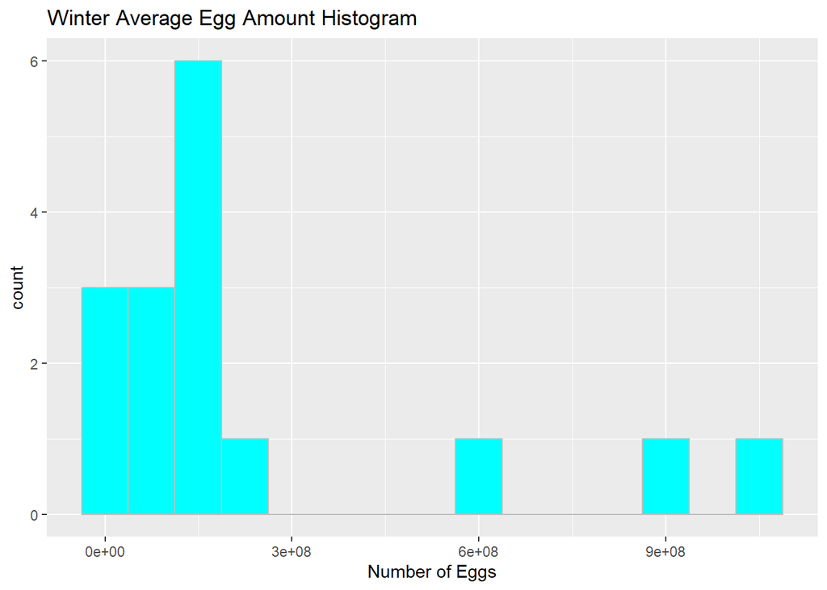

```r
ggplot(winter_egg, aes(x = avg_egg)) +
geom_histogram(binwidth = 75000000, fill = "cyan", col = "grey") +
labs(
title = "Winter Average Egg Amount Histogram",
x = "Number of Eggs"
)
```

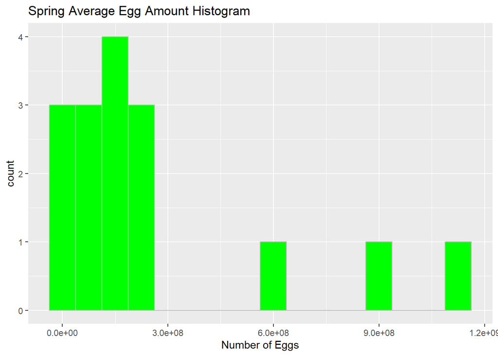

```r
ggplot(spring_egg, aes(x = avg_egg)) +
geom_histogram(binwidth = 75000000, fill = "green", col = "grey") +
labs(
title = "Spring Average Egg Amount Histogram",
x = "Number of Eggs"
)
```

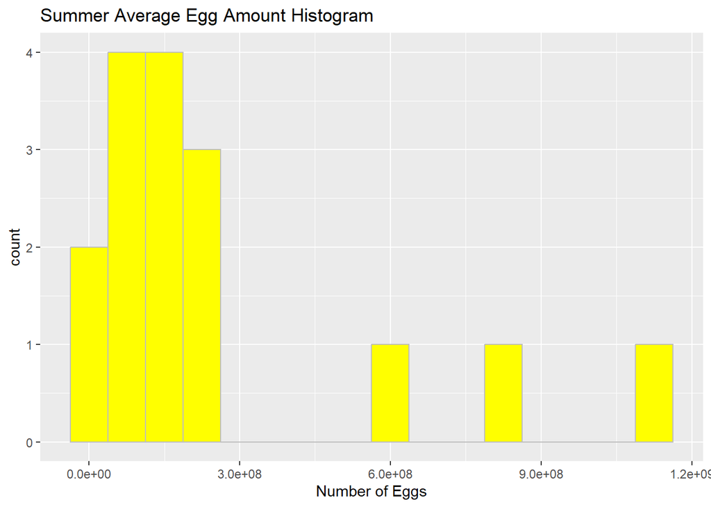

```r
ggplot(summer_egg, aes(x = avg_egg)) +
geom_histogram(binwidth = 75000000, fill = "yellow", col = "grey") +
labs(
title = "Summer Average Egg Amount Histogram",
x = "Number of Eggs"
)
```

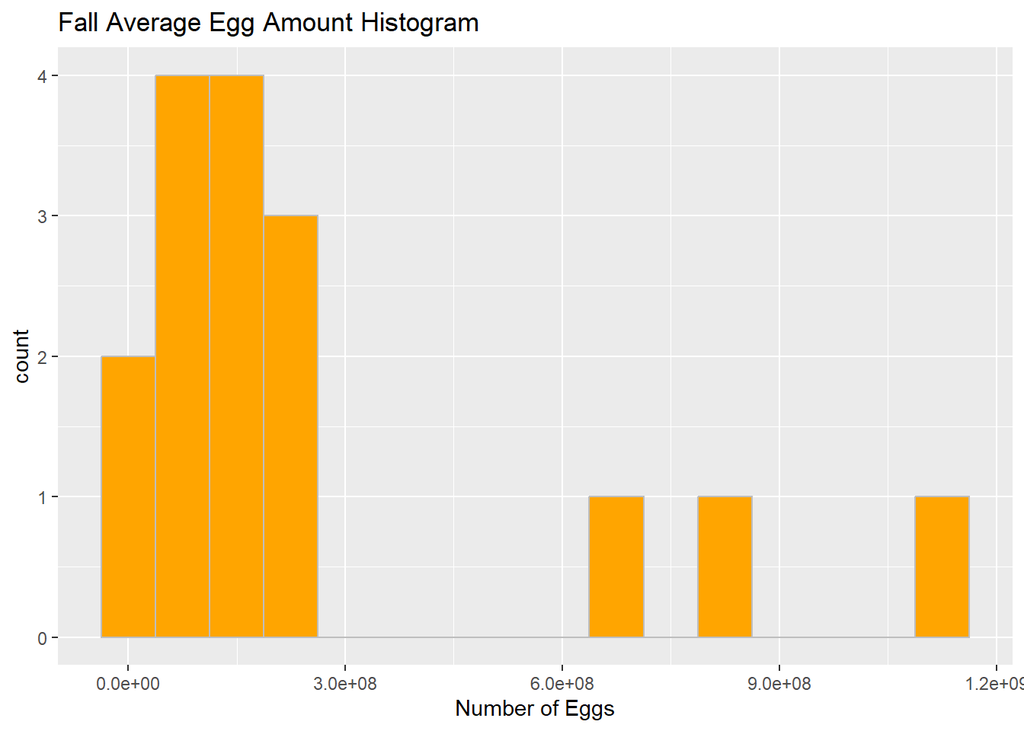

```r
ggplot(fall_egg, aes(x = avg_egg)) +
geom_histogram(binwidth = 75000000, fill = "orange", col = "grey") +
labs(
title = "Fall Average Egg Amount Histogram",
x = "Number of Eggs"
)
```

The seasonal histograms for the 16 states look fairly similar, suggesting that average egg production by season is not dramatically different across Winter, Spring, Summer, and Fall.

## 3.2 Boxplot by season (all states)

#### Side-by-side box plot for all 2023 data

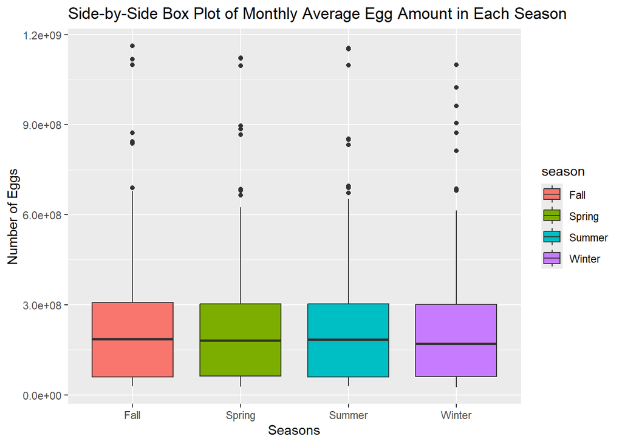

```r
ggplot(table_2023, aes(season, Value)) +
geom_boxplot(aes(y = Value, x = season, fill = season)) +
labs(
title = "Side-by-Side Box Plot of Monthly Average Egg Amount in Each Season",
y = "Number of Eggs",
x = "Seasons"
)
```

The boxplot shows that the distributions of monthly egg production are very similar across the four seasons, with similar medians and spreads.

## 3.3 Dot plot and summary tables

#### Set Period as an ordered factor for plotting and summaries

```r
table_2023$Period <- factor(
table_2023$Period,
levels = c("DEC", "JAN", "FEB", "MAR", "APR", "MAY",
"JUN", "JUL", "AUG", "SEP", "OCT", "NOV")
)
```

#### Dot plot of mean egg production by month

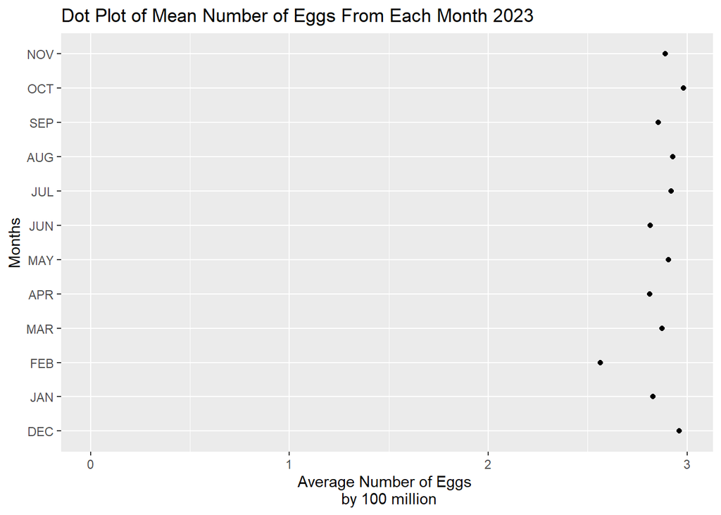

```r
ggplot(table_2023, aes(Period, Value)) +
geom_point(stat = "summary", fun = "mean") +
labs(
x = "Months",
y = "Average Number of Eggs \n by 100 million",
title = "Dot Plot of Mean Number of Eggs From Each Month 2023"
) +
scale_y_continuous(
limits = c(0, NA),
labels = function(x) x / 100000000
) +
coord_flip()
```

```r
# Find states that have all 12 months in 2023
complete_states <- table_2023 |>
  group_by(State) |>
  summarize(n_months = n_distinct(Period)) |>
  filter(n_months == 12) |>
  pull(State)

# Keep only those complete states
table_2023_complete <- table_2023 |>
  filter(State %in% complete_states)
```

#### Summary of eggs per season

```r
# Find states that have all 12 months in 2023 AND no missing Values
complete_states <- table_2023 |>
  group_by(State) |>
  summarize(
    n_months     = n_distinct(Period),
    n_non_missing = sum(!is.na(Value))
  ) |>
  filter(n_months == 12, n_non_missing == 12) |>
  pull(State)

# Keep only those complete states
table_2023_complete <- table_2023 |>
  filter(State %in% complete_states)

summary_egg <- table_2023 |>
group_by(season) |>
summarize(
Observation_number = length(Year),
Average_Egg_Count = round(mean(Value), 0),
SD_Egg_Count = round(sd(Value), 0)
)

summary_egg
```

```
# A tibble: 4 × 4
  season Observation_number Average_Egg_Count SD_Egg_Count
  <fct>               <int>             <dbl>        <dbl>
1 Fall                   54         290801852    311770421
2 Spring                 54         286409259    311831916
3 Summer                 54         288750000    313247303
4 Winter                 54         278461111    298083870
```

#### Summary of eggs per month

```r
summary_m_egg <- table_2023_complete |>
  group_by(Period) |>
  summarize(
    Observation_number = n_distinct(State),
    Average_Egg_Count  = round(mean(Value, na.rm = TRUE), 0 ),
    SD_Egg_Count       = round(sd(Value,   na.rm = TRUE), 0),
    num_month          = round(mean(month_num, na.rm = TRUE), 0)
  )

summary_m_egg[order(summary_m_egg$num_month), ]
```

```
# A tibble: 12 × 5
   Period Observation_number Average_Egg_Count SD_Egg_Count num_month
   <fct>               <int>             <dbl>        <dbl>     <dbl>
 1 JAN                    18         282955556    309183848         1
 2 FEB                    18         256372222    282674785         2
 3 MAR                    18         287361111    320678834         3
 4 APR                    18         281305556    312353957         4
 5 MAY                    18         290561111    320484993         5
 6 JUN                    18         281338889    310412436         6
 7 JUL                    18         292105556    323334874         7
 8 AUG                    18         292805556    323924050         8
 9 SEP                    18         285405556    314131017         9
10 OCT                    18         298105556    326104289        10
11 NOV                    18         288894444    312928591        11
12 DEC                    18         296055556    317253721        12
```

The month-by-month averages also stay in a similar range, giving more evidence that egg production is fairly stable across the calendar year.

# 4. Assumption Checks

#### Normality check using a Q-Q plot for egg production

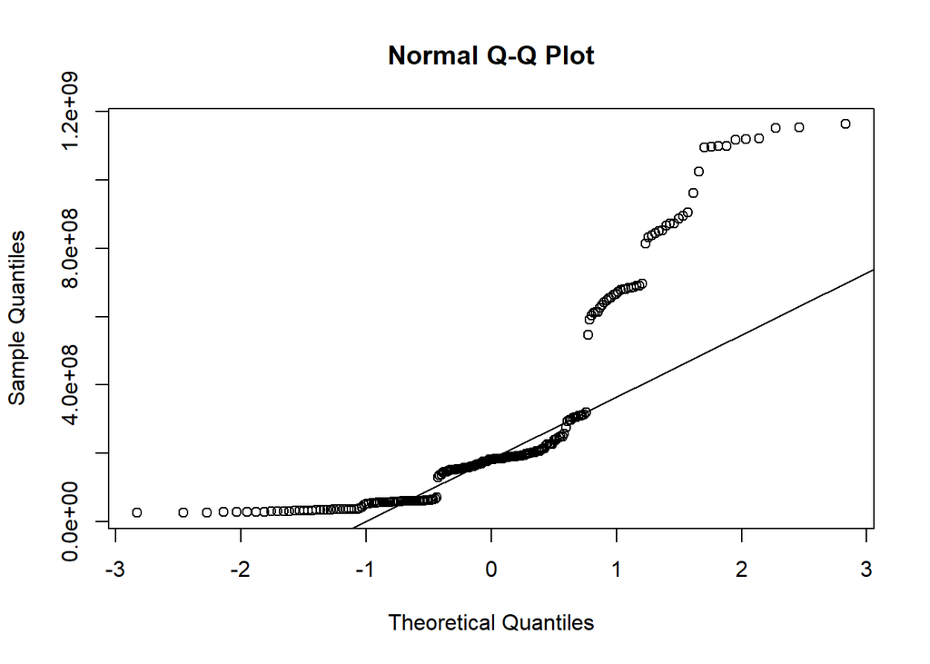

```r
qqnorm(table_2023$Value)
qqline(table_2023$Value)
```

# 5. Statistical Analysis: One-Way ANOVA

#### One-way ANOVA: egg production by season

```r
mod_egg <- aov(Value ~ season, data = table_2023)
summary(mod_egg)
```

```
             Df    Sum Sq   Mean Sq F value Pr(>F)
season        3 4.729e+15 1.576e+15   0.017  0.997
Residuals   212 2.022e+19 9.535e+16
```

From the ANOVA test, the test statistic is F = 0.017 with p = 0.997. Because the p-value is much larger than 0.05, we fail to reject the null hypothesis. There is not enough evidence to conclude that mean egg production differs across the four seasons in 2023.